# Part II - Presentation Of FordGo Bike trip Exploration

## Dataset Overview

> This data set includes information about individual rides made in a bike-sharing system covering the greater San Francisco Bay area.

```python
# import all packages and set plots to be embedded inline
import numpy as np
import pandas as pd
import matplotlib.pyplot as plt
import seaborn as sb

%matplotlib inline

# suppress warnings from final output
import warnings
warnings.simplefilter("ignore")
```

```python
# load in the dataset into a pandas dataframe
df = pd.read_csv("fordgobike_clean.csv")
```

```python
df.head(3)
```

|  | start_time | end_time | start_station_name | start_station_latitude | start_station_longitude | end_station_name | end_station_latitude | end_station_longitude | user_type | member_birth_year | member_gender | bike_share_for_all_trip | duration_minute | age |
| --- | --- | --- | --- | --- | --- | --- | --- | --- | --- | --- | --- | --- | --- | --- |
| 0 | 2019-02-28 23:55:35.104 | 2019-03-01 00:14:42.588 | Palm St at Willow St | 37.317298 | -121.884995 | San Jose Diridon Station | 37.329732 | -121.901782 | Subscriber | 1983 | Female | 0 | 19.116667 | 39 |
| 1 | 2019-02-28 23:49:47.699 | 2019-03-01 00:07:17.025 | Post St at Kearny St | 37.788975 | -122.403452 | Mission Playground | 37.759210 | -122.421339 | Subscriber | 1992 | Male | 0 | 17.483333 | 30 |
| 2 | 2019-02-28 23:57:57.211 | 2019-03-01 00:05:35.435 | Jones St at Post St | 37.787327 | -122.413278 | San Francisco Public Library (Grove St at Hyde... | 37.778768 | -122.415929 | Subscriber | 1996 | Female | 1 | 7.633333 | 26 |

> Note that the above cells have been set as "Skip"-type slides. That means that when the notebook is rendered as http slides, those cells won't show up.

## Start Station Location

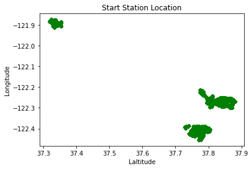

```python
df.plot('start_station_latitude','start_station_longitude', xlabel = 'Laltitude',ylabel = 'Longitude' , title = 'Start Station Location', kind = 'scatter' , c= 'green');
```

## Bike share per age

> You should have at least three visualizations in your presentation, but feel free to add more if you'd like!

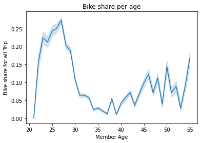

```python
sb.lineplot(df.age ,df.bike_share_for_all_trip).set(title="Bike share per age" , xlabel = 'Member Age',ylabel = "Bike share for all Trip");
```

## Trip Duration per Age For each gender

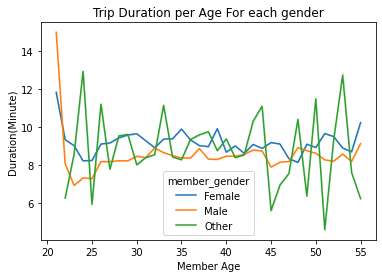

```python
sb.lineplot(df.age,df.duration_minute , hue = df.member_gender,ci = False).set(title ='Trip Duration per Age For each gender' ,xlabel ='Member Age' ,ylabel= 'Duration(Minute)');
```

> **Generate Slideshow**: Once you're ready to generate your slideshow, use the `jupyter nbconvert` command to generate the HTML slide show. . From the terminal or command line, use the following expression.

```python
!jupyter nbconvert Part_II_slide_deck_template.ipynb --to slides --post serve --no-input --no-prompt
```

```
^C
```

> This should open a tab in your web browser where you can scroll through your presentation. Sub-slides can be accessed by pressing 'down' when viewing its parent slide. Make sure you remove all of the quote-formatted guide notes like this one before you finish your presentation! At last, you can stop the Kernel.